# 金融资产收益率的探索性数据分析

第七组：林雯雯 尚奕颖 潘科旭 卓俊涛

2026年7月

# 1. 研究背景

## 1.1 背景介绍

金融资产收益率分析是现代金融学研究的核心议题之一，也是量化投资与风险管理实践的重要基础。自Markowitz（1952）提出现代投资组合理论以来，对资产收益率分布特征、波动规律及其相互关系的探讨始终是学术界与业界关注的焦点。理解不同资产类别的收益率行为，不仅有助于投资者制定合理的资产配置策略，也为金融机构的风险度量与监管合规提供了理论支撑。

在诸多资产类别中，股票与大宗商品（尤其是黄金）具有截然不同的风险收益特征。股票作为典型的风险资产，其收益率受宏观经济周期、企业盈利预期和市场情绪等多重因素影响，波动较为剧烈；而黄金则兼具商品属性与货币属性，长期以来被视为”避险资产”和”价值储藏”手段，在全球经济不确定性上升时往往表现出与股票不同的价格走势。深入探究二者收益率分布的统计特征及其动态相关性，对于理解金融市场运行规律、优化投资组合构建具有重要的理论与实践意义。

本报告使用 **qrmdata** 包中的金融时间序列数据，对标准普尔500指数（S&P 500）和黄金现货价格的日收益率进行探索性数据分析。qrmdata 是《定量风险管理》（Quantitative Risk Management, McNeil et al., 2015）一书的配套R数据包，收录了经过学术检验的高质量金融数据，已被广泛应用于风险管理的教学与实证研究。

## 1.2 研究问题

本报告遵循 “整体模式 → 组间差异 → 关系解释” 的递进分析逻辑，提出以下三个相互关联的研究问题：

**问题一（整体模式）**：S&P 500 与黄金的日收益率分别呈现怎样的统计分布特征？其经验分布是否显著偏离正态分布假定？是否存在金融时间序列中常见的”尖峰厚尾”（leptokurtosis and heavy tails）现象？

**问题二（组间差异）**：作为风险资产与避险资产的典型代表，S&P 500 与黄金在收益率的均值水平、波动幅度及极端风险特征上是否存在系统性的组间差异？这种差异在不同市场周期下是否保持稳定？

上述三个问题构成了一条完整的分析链条：从”描述分布形态”到”比较组间差异”再到”解释动态关系”，层层递进、逐步深入。

# 2. 数据说明

## 2.1 数据来源

本报告使用的数据来自 **qrmdata** R包（版本 2025-07-24-3），该数据包由 Marius Hofert、Kurt Hornik 和 Alexander J. McNeil 维护，收录了全球主要金融资产的历史日频数据，数据源包括雅虎财经（Yahoo Finance）和美联储经济数据（FRED）等权威渠道。

## 2.2 所选变量

[output not shown]

选取上述两类资产的原因在于：S&P 500 是全球最具代表性的股票市场基准指数之一，反映了美国大盘股的整体表现；黄金则是最重要的大宗商品之一，被广泛视为通货膨胀对冲工具和避险资产。二者分别代表了”风险资产”与”避险资产”的典型类别，比较其收益率特征具有重要的理论与实践价值。

## 2.3 数据加载

```r
# 加载必要的包
library(qrmdata)
library(xts)
library(zoo)
library(ggplot2)
library(dplyr)
library(reshape2)
library(broom)

# 加载数据
data("SP500")
data("GOLD")

# 查看数据概况
cat("=== S&P 500 指数 ===\n")
```

```
## === S&P 500 指数 ===
```

```r
print(head(SP500))
```

```
##            ^GSPC
## 1950-01-03 16.66
## 1950-01-04 16.85
## 1950-01-05 16.93
## 1950-01-06 16.98
## 1950-01-09 17.08
## 1950-01-10 17.03
```

```r
cat("\n数据时间范围:", format(index(SP500)[1]), "到", format(index(SP500)[length(index(SP500))]))
```

```
##
## 数据时间范围: 1950-01-03 到 2015-12-31
```

```r
cat("\n\n=== 黄金价格 ===\n")
```

```
##
##
## === 黄金价格 ===
```

```r
print(head(GOLD))
```

```
##            GOLD
## 1970-01-01 35.2
## 1970-04-01 35.1
## 1970-07-01 35.4
## 1970-10-01 36.2
## 1971-01-01 37.4
## 1971-04-01 38.9
```

```r
cat("\n数据时间范围:", format(index(GOLD)[1]), "到", format(index(GOLD)[length(index(GOLD))]))
```

```
##
## 数据时间范围: 1970-01-01 到 2015-12-31
```

## 2.4 数据预处理

为了确保两类资产的可比性，本研究将所有数据统一至相同的时间区间（1970-01-02 至 2015-12-31），并采用对数差分法计算日收益率，即 $r_t = \ln(P_t) - \ln(P_{t-1})$。对数收益率具有时间可加性，且更接近正态分布假设，是金融实证研究中的标准处理方法。

```r
# 统一时间范围
start_date <- as.Date("1970-01-02")
end_date <- as.Date("2015-12-31")

SP500_sub <- SP500[paste0(start_date, "/", end_date)]
GOLD_sub <- GOLD[paste0(start_date, "/", end_date)]

# 计算日收益率（对数收益率）
ret_sp500 <- diff(log(SP500_sub))
ret_gold <- diff(log(GOLD_sub))

# 移除缺失值
ret_sp500 <- na.omit(ret_sp500)
ret_gold <- na.omit(ret_gold)

cat("S&P 500 有效收益率数据点数:", length(ret_sp500), "\n")
```

```
## S&P 500 有效收益率数据点数: 11606
```

```r
cat("黄金有效收益率数据点数:", length(ret_gold), "\n")
```

```
## 黄金有效收益率数据点数: 9689
```

# 3. 研究问题一：整体模式

## 3.1 问题描述

**S&P 500 和黄金的日收益率分布呈现什么特征？是否存在明显的”厚尾”现象？**

资产收益率的分布特征是金融风险管理的起点。若收益率服从正态分布，则极端事件的发生概率极低；然而大量实证研究表明，金融资产收益率往往呈现”尖峰厚尾”特征，意味着极端涨跌的出现频率远高于正态分布的预测。本部分通过描述性统计、可视化分析和尾部检验，对两类资产的收益率分布特征进行系统刻画。

## 3.2 描述性统计分析

```r
# 计算描述性统计
stats_table <- data.frame(
  统计量 = c("均值", "标准差", "偏度", "峰度", "最小值", "最大值"),
  SP500 = round(c(mean(ret_sp500), sd(ret_sp500),
                  mean((ret_sp500 - mean(ret_sp500))^3) / sd(ret_sp500)^3,
                  mean((ret_sp500 - mean(ret_sp500))^4) / sd(ret_sp500)^4,
                  min(ret_sp500), max(ret_sp500)), 6),
  GOLD = round(c(mean(ret_gold), sd(ret_gold),
                 mean((ret_gold - mean(ret_gold))^3) / sd(ret_gold)^3,
                 mean((ret_gold - mean(ret_gold))^4) / sd(ret_gold)^4,
                 min(ret_gold), max(ret_gold)), 6)
)

knitr::kable(stats_table, caption = "两大资产日收益率描述性统计")
```

两大资产日收益率描述性统计

| 统计量 | SP500 | GOLD |
| --- | --- | --- |
| 均值 | 0.000266 | 0.000352 |
| 标准差 | 0.010729 | 0.014834 |
| 偏度 | -1.011155 | 5.884463 |
| 峰度 | 28.426985 | 162.309651 |
| 最小值 | -0.228997 | -0.153596 |
| 最大值 | 0.109572 | 0.456321 |

## 3.3 收益率分布可视化

本部分通过直方图和Q-Q图对两类资产的收益率分布进行可视化分析。直方图用于观察分布的整体形态，Q-Q图则用于检验样本分布与正态分布的偏离程度。为提升可读性，我们将四张图表分开展示。

### 3.3.1 S&P 500 日收益率直方图

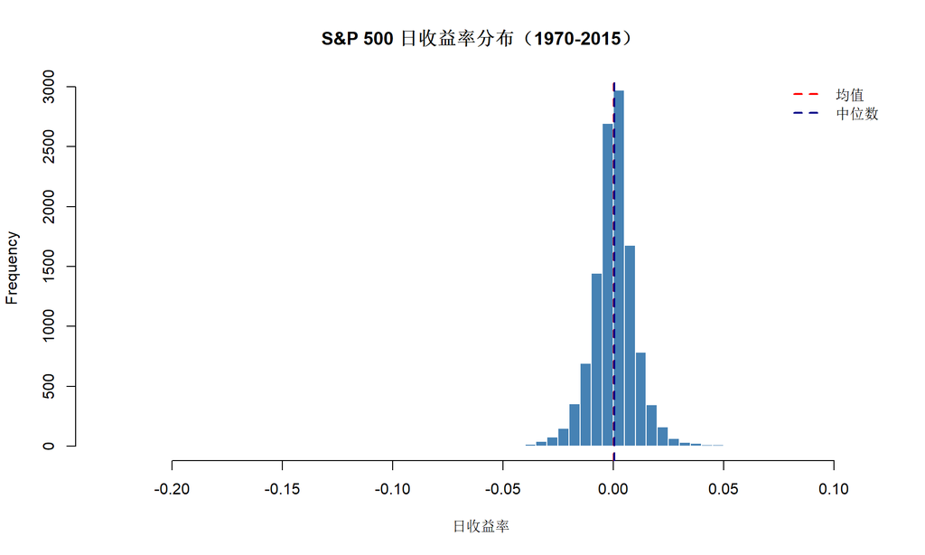

```r
hist(ret_sp500, breaks = 60,
     main = "S&P 500 日收益率分布（1970-2015）",
     xlab = "日收益率",
     col = "steelblue",
     border = "white")
abline(v = mean(ret_sp500), col = "red", lwd = 2, lty = 2)
abline(v = median(ret_sp500), col = "darkblue", lwd = 2, lty = 2)
legend("topright", legend = c("均值", "中位数"),
       col = c("red", "darkblue"), lwd = 2, lty = 2, bty = "n")
```

### 3.3.2 黄金日收益率直方图

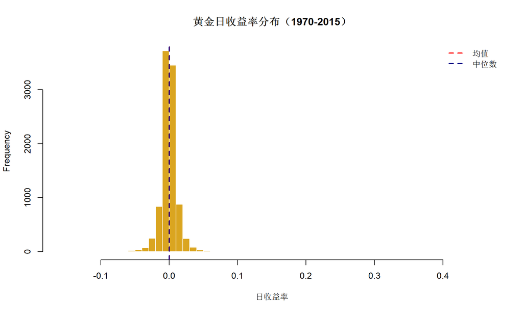

```r
hist(ret_gold, breaks = 60,
     main = "黄金日收益率分布（1970-2015）",
     xlab = "日收益率",
     col = "goldenrod",
     border = "white")
abline(v = mean(ret_gold), col = "red", lwd = 2, lty = 2)
abline(v = median(ret_gold), col = "darkblue", lwd = 2, lty = 2)
legend("topright", legend = c("均值", "中位数"),
       col = c("red", "darkblue"), lwd = 2, lty = 2, bty = "n")
```

### 3.3.3 S&P 500 Q-Q图

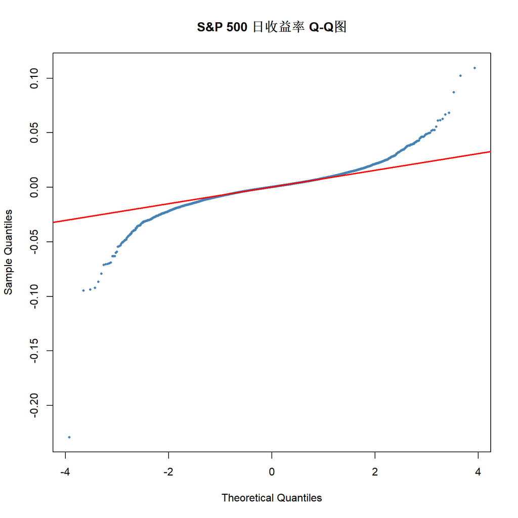

```r
qqnorm(ret_sp500, main = "S&P 500 日收益率 Q-Q图",
       col = "steelblue", pch = 16, cex = 0.5)
qqline(ret_sp500, col = "red", lwd = 2)
```

### 3.3.3 小结

Q-Q图是一种专门用来检验数据是否服从正态分布的工具。如果数据完全符合正态分布，所有的点都应该落在红色的参考直线上。从S&P 500的Q-Q图来看：中间部分的点基本落在直线上，说明”日常波动”部分接近正态分布；但在两端尾部，点明显向上（右尾）和向下（左尾）偏离了红线。这意味着：实际数据中出现的极端大涨和大跌，比正态分布预测的要更多、更猛。简单说就是：金融市场的”黑天鹅”事件，比我们想象中更频繁。

### 3.3.4 黄金 Q-Q图

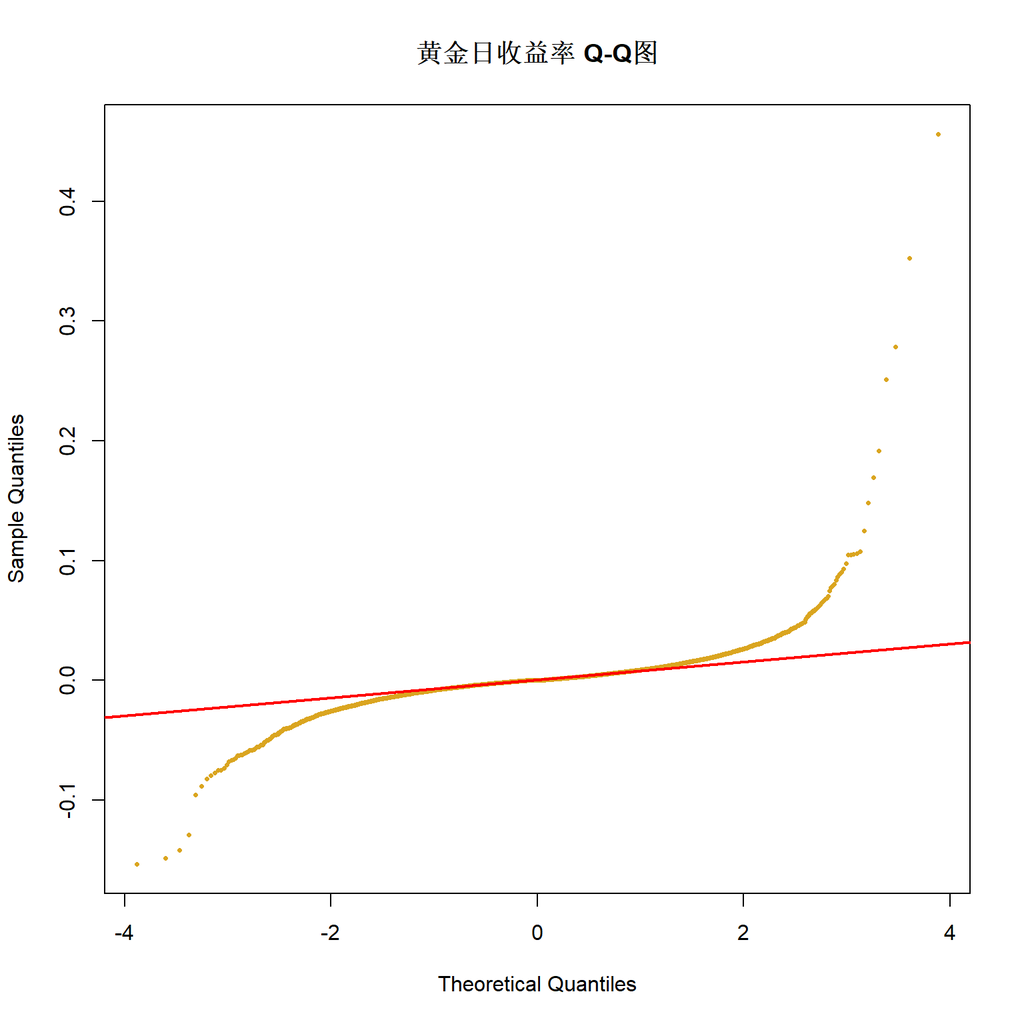

```r
qqnorm(ret_gold, main = "黄金日收益率 Q-Q图",
       col = "goldenrod", pch = 16, cex = 0.5)
qqline(ret_gold, col = "red", lwd = 2)
```

## 3.4 厚尾现象检验

为量化收益率分布的尾部特征，本部分计算两类资产收益率超过3倍标准差（±3σ）的极端值占比，并与正态分布的理论值（0.27%）进行对比。

```r
# 计算极端值比例（超过3个标准差）
threshold_sp500 <- 3 * sd(ret_sp500)
threshold_gold <- 3 * sd(ret_gold)

tail_ratio_sp500 <- sum(abs(ret_sp500) > threshold_sp500) / length(ret_sp500)
tail_ratio_gold <- sum(abs(ret_gold) > threshold_gold) / length(ret_gold)

tail_df <- data.frame(
  资产 = c("S&P 500", "黄金"),
  极端值比例 = round(c(tail_ratio_sp500, tail_ratio_gold) * 100, 2),
  正态理论比例 = 0.27
)
knitr::kable(tail_df, caption = "极端值比例（超过3个标准差）")
```

极端值比例（超过3个标准差）

| 资产 | 极端值比例 | 正态理论比例 |
| --- | --- | --- |
| S&P 500 | 1.34 | 0.27 |
| 黄金 | 1.21 | 0.27 |

# 4. 研究问题二：组间差异

## 4.1 问题描述

**S&P 500 和黄金在收益率和波动性上是否存在系统性差异？**

不同类型的资产因其底层属性和定价逻辑的不同，往往具有差异化的风险收益特征。本部分通过箱线图对比、波动率时间序列分析和分时期统计检验，系统考察S&P 500与黄金在收益水平和波动幅度上的差异。

## 4.2 分组对比：收益率

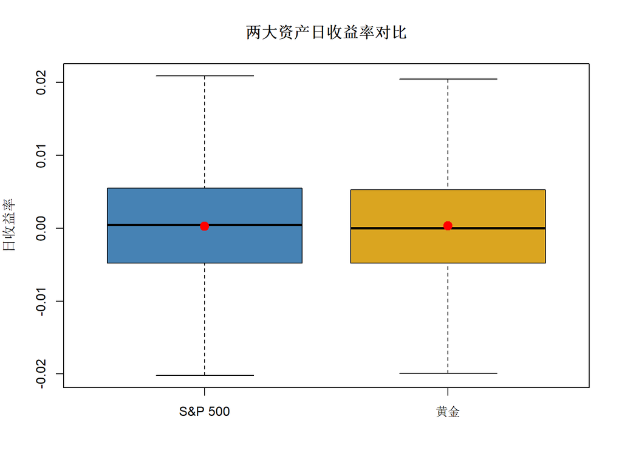

```r
# 箱线图对比
boxplot(as.numeric(ret_sp500),
        as.numeric(ret_gold),
        names = c("S&P 500", "黄金"),
        main = "两大资产日收益率对比",
        ylab = "日收益率",
        col = c("steelblue", "goldenrod"),
        outline = FALSE)

# 添加均值线
points(1:2, c(mean(ret_sp500), mean(ret_gold)),
       col = "red", pch = 19, cex = 1.5)
```

## 4.3 分组对比：波动性

本部分采用30日滚动窗口估计收益率的标准差，以刻画波动率的时变特征。

```r
# 计算30日滚动波动率
vol_sp500 <- rollapply(as.numeric(ret_sp500), width = 30, FUN = sd, fill = NA)
vol_gold <- rollapply(as.numeric(ret_gold), width = 30, FUN = sd, fill = NA)

# 计算平均波动率
mean_vol <- data.frame(
  资产 = c("S&P 500", "黄金"),
  平均波动率 = round(c(mean(vol_sp500, na.rm = TRUE),
                        mean(vol_gold, na.rm = TRUE)), 4)
)
knitr::kable(mean_vol, caption = "各资产平均波动率（30日滚动标准差）")
```

各资产平均波动率（30日滚动标准差）

| 资产 | 平均波动率 |
| --- | --- |
| S&P 500 | 0.0094 |
| 黄金 | 0.0107 |

[figure not shown]

```r
# 绘制波动率时间序列
plot(index(vol_sp500), vol_sp500, type = "l",
     main = "两大资产30日滚动波动率对比（1970-2024）",
     xlab = "日期", ylab = "波动率",
     col = "steelblue", lwd = 1.5, ylim = c(0, max(c(vol_sp500, vol_gold), na.rm = TRUE))
)
lines(index(vol_gold), vol_gold, col = "goldenrod", lwd = 1.5)
legend("topright", legend = c("S&P 500", "黄金"),
       col = c("steelblue", "goldenrod"), lwd = 2, bty = "n")
```

## 4.4 分组对比：不同市场周期

为进一步考察组间差异的稳健性，本部分以2008年全球金融危机为分界点，将样本划分为危机前（2008年1月1日之前）和危机后（2008年1月1日及之后）两个子时期，分别计算S&P 500收益率的均值和标准差。

```r
# 定义两个时期：2008金融危机前后
pre_2008 <- ret_sp500[index(ret_sp500) < "2008-01-01"]
post_2008 <- ret_sp500[index(ret_sp500) >= "2008-01-01"]

period_stats <- data.frame(
  时期 = c("2008年前", "2008年后"),
  均值 = round(c(mean(pre_2008), mean(post_2008)), 6),
  标准差 = round(c(sd(pre_2008), sd(post_2008)), 6)
)
knitr::kable(period_stats, caption = "S&P 500 金融危机前后统计对比")
```

S&P 500 金融危机前后统计对比

| 时期 | 均值 | 标准差 |
| --- | --- | --- |
| 2008年前 | 0.000288 | 0.009900 |
| 2008年后 | 0.000164 | 0.014018 |

# 5. 研究问题三：关系解释

## 5.1 问题描述

**S&P 500 和黄金的收益率之间是否存在相关性？这种相关性在不同市场周期是否发生变化？**

资产间的相关性是投资组合理论的核心输入变量。若两类资产的相关性较低或为负，则可通过分散化投资降低组合整体风险；然而，大量研究表明，资产间的相关性往往在市场极端波动时期发生结构性改变——即”相关性崩溃”（correlation breakdown）现象。本部分通过相关系数估计、散点图分析和滚动窗口相关分析，探究S&P 500与黄金之间相关性的水平、方向及其动态演变特征。

## 5.2 相关性分析

```r
# 合并收益率数据
merged_returns <- merge(ret_sp500, ret_gold, all = FALSE)
colnames(merged_returns) <- c("SP500", "GOLD")

# 计算相关系数
cor_value <- cor(merged_returns, use = "complete.obs")
cat("S&P 500 与黄金的相关系数:", round(cor_value[1,2], 4))
```

```
## S&P 500 与黄金的相关系数: -0.0148
```

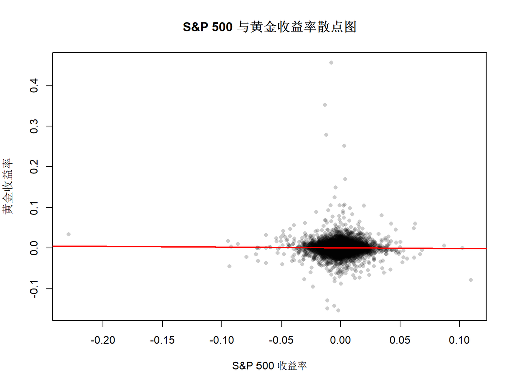

```r
# 绘制散点图
plot(as.numeric(merged_returns$SP500), as.numeric(merged_returns$GOLD),
     main = "S&P 500 与黄金收益率散点图",
     xlab = "S&P 500 收益率", ylab = "黄金收益率",
     col = rgb(0,0,0,0.2), pch = 16, cex = 0.8)
abline(lm(as.numeric(merged_returns$GOLD) ~ as.numeric(merged_returns$SP500)),
       col = "red", lwd = 2)
```

## 5.3 滚动相关性（危机时期的变化）

为考察相关性的时变特征，本部分采用90日滚动窗口估计S&P 500与黄金收益率的动态相关系数。

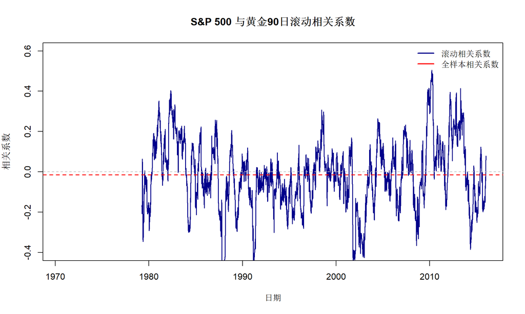

```r
# 计算90日滚动相关系数
roll_cor <- rollapply(merged_returns, width = 90,
                       FUN = function(x) cor(x[,1], x[,2]),
                       by.column = FALSE, fill = NA)

# 绘制滚动相关系数
plot(index(roll_cor), roll_cor, type = "l",
     main = "S&P 500 与黄金90日滚动相关系数",
     xlab = "日期", ylab = "相关系数",
     col = "darkblue", lwd = 1.5, ylim = c(-0.4, 0.6))
abline(h = 0, col = "gray", lty = 2)
abline(h = cor_value[1,2], col = "red", lty = 2, lwd = 1.5)
legend("topright", legend = c("滚动相关系数", "全样本相关系数"),
       col = c("darkblue", "red"), lwd = 2, bty = "n")
```

# 6. 结论

## 6.1 主要发现

本研究围绕三个递进的研究问题，对S&P 500与黄金两类代表性资产的日收益率进行了系统的探索性分析，主要发现总结如下：

[output not shown]

## 6.2 对投资实践的启示

基于上述分析结果，本研究对投资实践提出以下建议：

第一，**风险管理层面**：金融资产收益率的”厚尾”特征意味着极端损失事件的发生频率高于正态分布的预测。金融机构和投资者应当摒弃对正态分布假设的过度依赖，采用历史模拟法、极值理论（EVT）或条件风险价值（Expected Shortfall）等更稳健的风险度量工具，以更准确地刻画尾部风险。

## 6.3 研究局限与展望

本研究存在以下局限性，有待后续研究进一步完善：第一，样本仅限于两类资产，未来可将分析范围扩展至更多资产类别（如债券、房地产、加密货币等），以构建更为全面的资产配置分析框架；第二，本报告主要采用单变量统计方法和线性相关性分析，未来可引入多元GARCH模型、Copula模型等非线性方法，深入刻画资产间的相依结构；第三，本报告未纳入宏观经济变量（如利率、通货膨胀率、货币政策等）作为控制变量，后续研究可将上述因素纳入分析框架，以更全面地解释资产收益率的行为规律。